# Imblearn libary is used to handle imbalanced data

# Jupyter notebook

!pip install imblearn --user

!pip install imbalanced-learn --user

# !pip install -U imbalanced-learn

# conda install -c conda-forge imbalanced-learn

# Restart the kernel after successful installation of the library

```python
# To help with reading and manipulation of data
import numpy as np
from numpy import array
import pandas as pd

# To help with data visualization
import matplotlib.pyplot as plt
import seaborn as sns

# To split the data
from sklearn.model_selection import train_test_split

# To impute missing values
from sklearn.impute import SimpleImputer

# To do one-hot encoding
from sklearn.preprocessing import OneHotEncoder

# To build a decision tree model
from sklearn.tree import DecisionTreeClassifier

# To get different performance metrics
import sklearn.metrics as metrics
from sklearn.metrics import (
    classification_report,
    confusion_matrix,
    recall_score,
    accuracy_score,
    precision_score,
    f1_score,
)


# To undersample and oversample the data
from imblearn.over_sampling import SMOTE
from imblearn.under_sampling import RandomUnderSampler

# To suppress warnings
import warnings
warnings.filterwarnings("ignore")
```

Exploratory Data Analysis and Insights

- Problem definition, questions to be answered - Data background and contents - Univariate analysis - Bivariate analysis - Key meaningful observations on individual variables and the relationship between variables

```python
Bank = pd.read_csv('BankChurners.csv',sep=',')
data=Bank.copy()
```

```python
data.info()#see missing info, size, names, and datatyes
```

```
<class 'pandas.core.frame.DataFrame'>
RangeIndex: 10127 entries, 0 to 10126
Data columns (total 21 columns):
 #   Column                    Non-Null Count  Dtype
---  ------                    --------------  -----
 0   CLIENTNUM                 10127 non-null  int64
 1   Attrition_Flag            10127 non-null  object
 2   Customer_Age              10127 non-null  int64
 3   Gender                    10127 non-null  object
 4   Dependent_count           10127 non-null  int64
 5   Education_Level           8608 non-null   object
 6   Marital_Status            9378 non-null   object
 7   Income_Category           10127 non-null  object
 8   Card_Category             10127 non-null  object
 9   Months_on_book            10127 non-null  int64
 10  Total_Relationship_Count  10127 non-null  int64
 11  Months_Inactive_12_mon    10127 non-null  int64
 12  Contacts_Count_12_mon     10127 non-null  int64
 13  Credit_Limit              10127 non-null  float64
 14  Total_Revolving_Bal       10127 non-null  int64
 15  Avg_Open_To_Buy           10127 non-null  float64
 16  Total_Amt_Chng_Q4_Q1      10127 non-null  float64
 17  Total_Trans_Amt           10127 non-null  int64
 18  Total_Trans_Ct            10127 non-null  int64
 19  Total_Ct_Chng_Q4_Q1       10127 non-null  float64
 20  Avg_Utilization_Ratio     10127 non-null  float64
dtypes: float64(5), int64(10), object(6)
memory usage: 1.6+ MB
```

Marital status and education level have nulls, others do not it seems

```python
def histogram_boxplot(data, feature, figsize=(12, 7), kde=False, bins=None):
    """
    Boxplot and histogram combined

    data: dataframe
    feature: dataframe column
    figsize: size of figure (default (12,7))
    kde: whether to show the density curve (default False)
    bins: number of bins for histogram (default None)
    """
    f2, (ax_box2, ax_hist2) = plt.subplots(
        nrows=2,  # Number of rows of the subplot grid= 2
        sharex=True,  # x-axis will be shared among all subplots
        gridspec_kw={"height_ratios": (0.25, 0.75)},
        figsize=figsize,
    )  # creating the 2 subplots
    sns.boxplot(
        data=data, x=feature, ax=ax_box2, showmeans=True, color="violet"
    )  # boxplot will be created and a star will indicate the mean value of the column
    sns.histplot(
        data=data, x=feature, kde=kde, ax=ax_hist2, bins=bins, palette="winter"
    ) if bins else sns.histplot(
        data=data, x=feature, kde=kde, ax=ax_hist2
    )  # For histogram
    ax_hist2.axvline(
        data[feature].mean(), color="green", linestyle="--"
    )  # Add mean to the histogram
    ax_hist2.axvline(
        data[feature].median(), color="black", linestyle="-"
    )  # Add median to the histogram
```

```python
def labeled_barplot(data, feature, perc=False, n=None):
    """
    Barplot with percentage at the top

    data: dataframe
    feature: dataframe column
    perc: whether to display percentages instead of count (default is False)
    n: displays the top n category levels (default is None, i.e., display all levels)
    """

    total = len(data[feature])  # length of the column
    count = data[feature].nunique()
    if n is None:
        plt.figure(figsize=(count + 1, 5))
    else:
        plt.figure(figsize=(n + 1, 5))

    plt.xticks(rotation=90, fontsize=15)
    ax = sns.countplot(
        data=data,
        x=feature,
        palette="Paired",
        order=data[feature].value_counts().index[:n].sort_values(),
    )

    for p in ax.patches:
        if perc == True:
            label = "{:.1f}%".format(
                100 * p.get_height() / total
            )  # percentage of each class of the category
        else:
            label = p.get_height()  # count of each level of the category

        x = p.get_x() + p.get_width() / 2  # width of the plot
        y = p.get_height()  # height of the plot

        ax.annotate(
            label,
            (x, y),
            ha="center",
            va="center",
            size=12,
            xytext=(0, 5),
            textcoords="offset points",
        )  # annotate the percentage

    plt.show()  # show the plot
```

Univariate

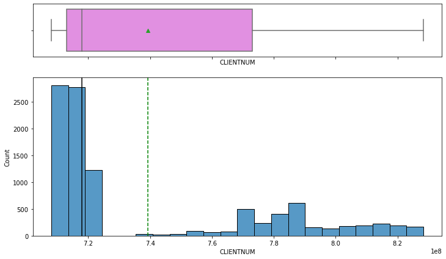

```python
histogram_boxplot(data,'CLIENTNUM')
```

This hardly seems useful

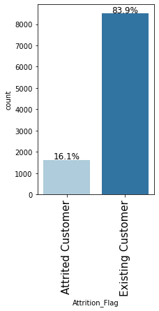

```python
labeled_barplot(data,"Attrition_Flag",perc=True)
```

Over 80% are existing customers, our target

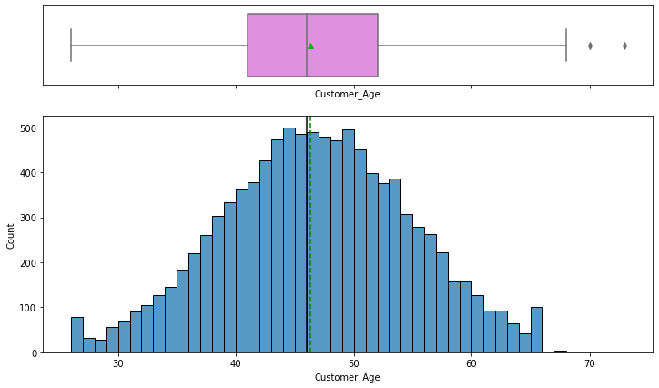

```python
histogram_boxplot(data,'Customer_Age')
```

Fairly well distributed with an average around 45 and only a few outlier above 65 or below 25

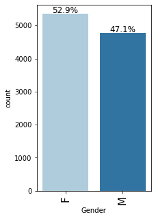

```python
labeled_barplot(data,"Gender",perc=True)
```

About 50%, seems to be the ratio of men to women in the US perhaps?

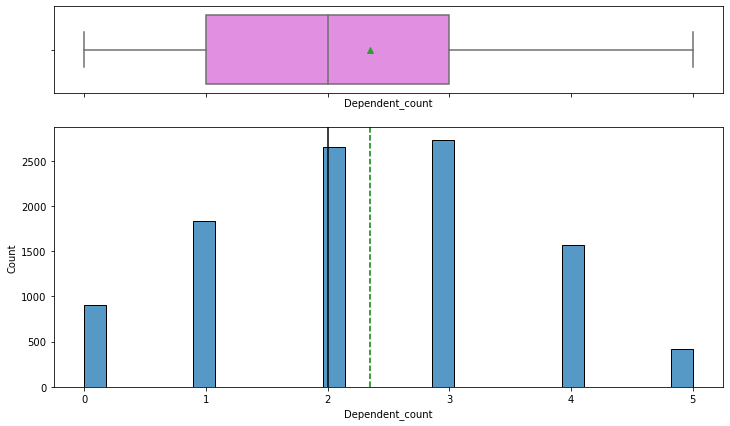

```python
histogram_boxplot(data,'Dependent_count')
```

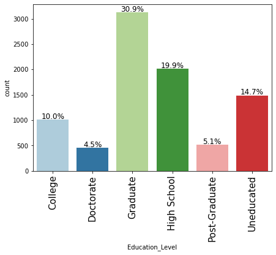

```python
labeled_barplot(data,"Education_Level",perc=True)
```

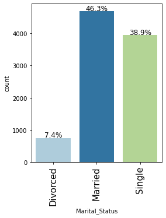

```python
labeled_barplot(data,"Marital_Status",perc=True)
```

About half are married and many are single. Only a few divorced

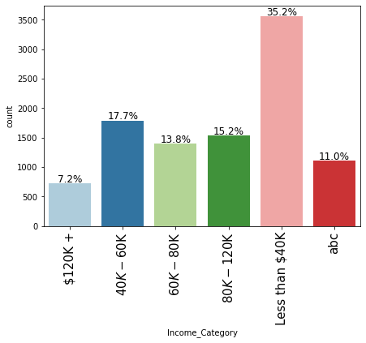

```python
labeled_barplot(data,"Income_Category",perc=True)
```

Plurality below 40k, only a handful above 120k, I assume abc is a type, I will replace it with "Less than $40K" as that is mode

```python
data['Income_Category']=data['Income_Category'].replace('abc','Less than $40K')
```

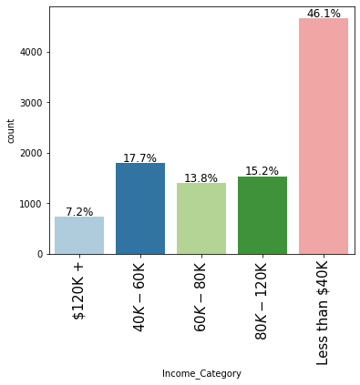

```python
labeled_barplot(data,"Income_Category",perc=True)
```

Ok better

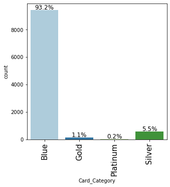

```python
labeled_barplot(data,"Card_Category",perc=True)
```

Lower pier= more likelty

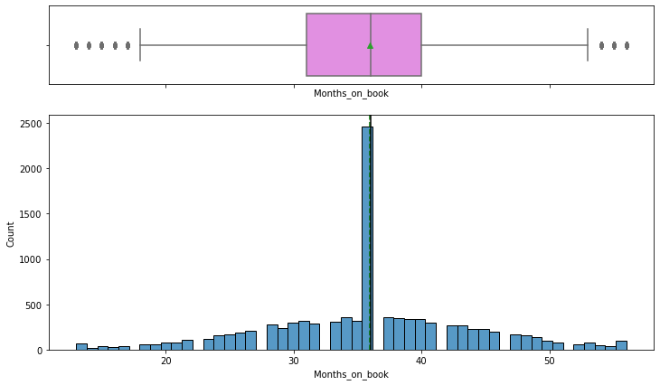

```python
histogram_boxplot(data,'Months_on_book')
```

Suprisingly normal median and mean bioth about 35

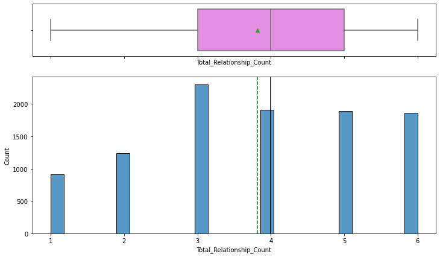

```python
histogram_boxplot(data,'Total_Relationship_Count')
```

Slighy lead tail

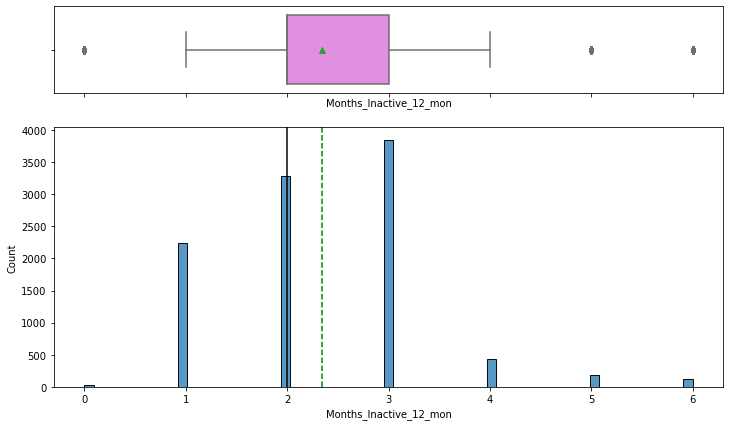

```python
histogram_boxplot(data,'Months_Inactive_12_mon')
```

Some outliers, nothing of note.

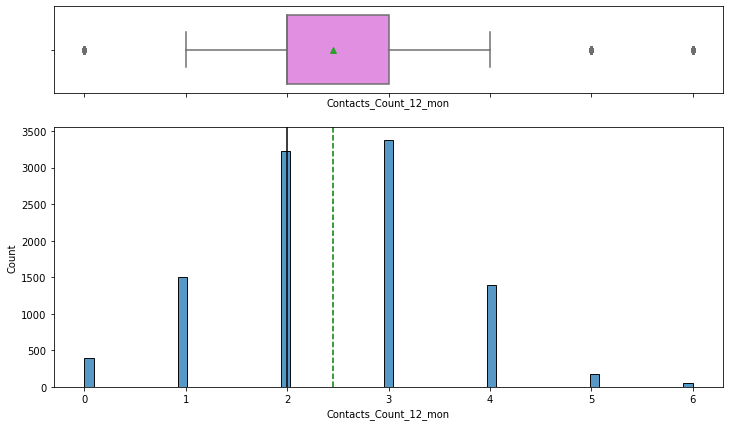

```python
histogram_boxplot(data,'Contacts_Count_12_mon')
```

Some outliers, nothing of note.

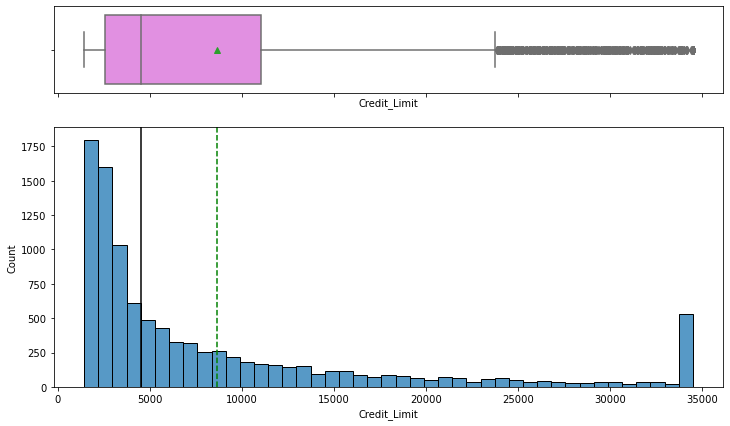

```python
histogram_boxplot(data,'Credit_Limit')
```

High scew

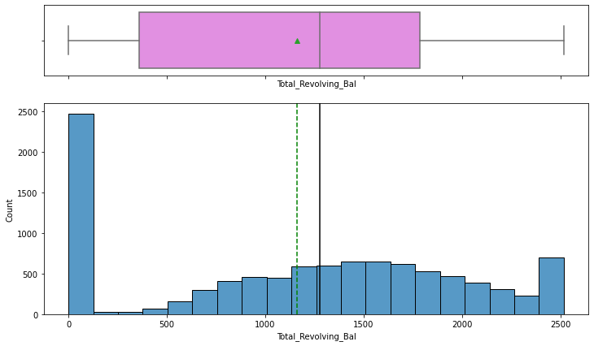

```python
histogram_boxplot(data,'Total_Revolving_Bal')
```

Some outlier at 0

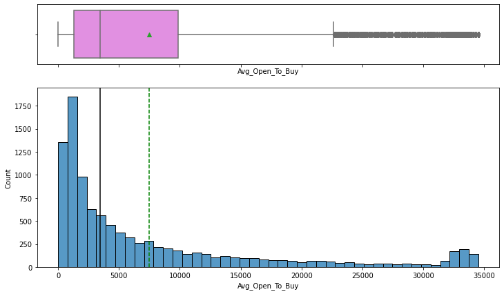

```python
histogram_boxplot(data,'Avg_Open_To_Buy')
```

High skew

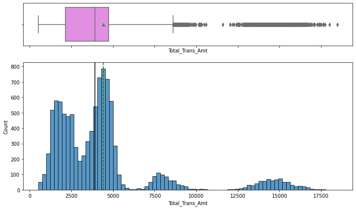

```python
histogram_boxplot(data,'Total_Trans_Amt')
```

4 peaks

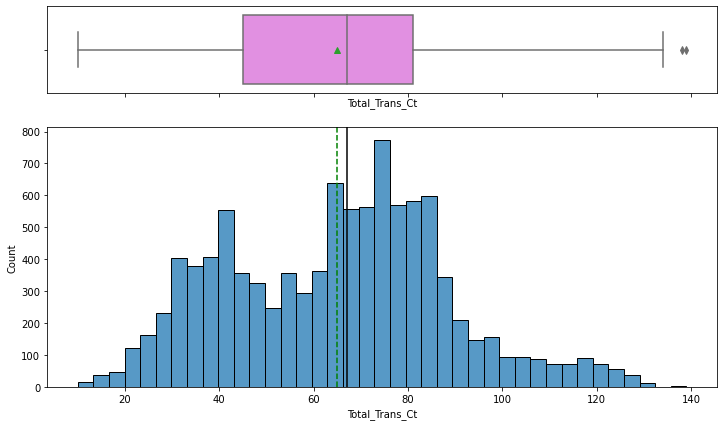

```python
histogram_boxplot(data,'Total_Trans_Ct')
```

Normal

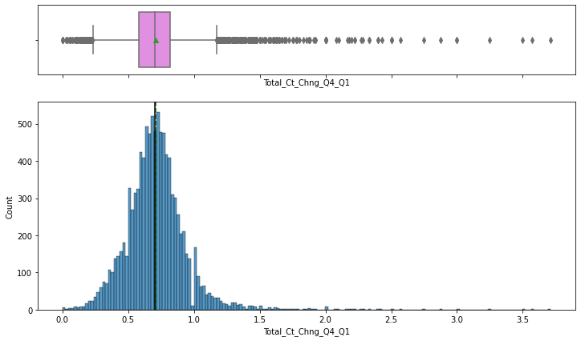

```python
histogram_boxplot(data,'Total_Ct_Chng_Q4_Q1')
```

Lots of outliers

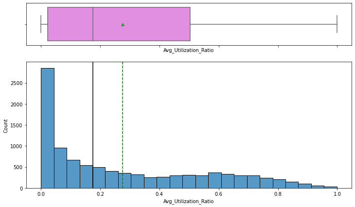

```python
histogram_boxplot(data,'Avg_Utilization_Ratio')
```

Again skewed

bivariate

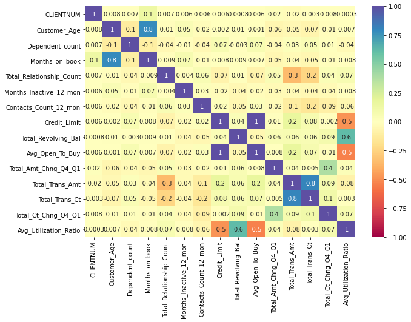

```python
plt.figure(figsize=(10,7))
sns.heatmap(data.corr(),annot=True,vmin=-1,vmax=1,fmt='.1g',cmap="Spectral")
plt.show()
```

1 credit limit and avg open to buy, drop credit Above 0.8: customer age and months on book total trans amt and total trans ct

```python
data.drop(['Credit_Limit'], axis=1, inplace=True)
```

Above 0.5 credit limit and avg utilization ratio, totasl revolving bal and avg utilization ratio, and avg open to buy abd avg utilization ratio

```python
def stacked_barplot(data, predictor, target):
    """
    Print the category counts and plot a stacked bar chart

    data: dataframe
    predictor: independent variable
    target: target variable
    """
    count = data[predictor].nunique()
    sorter = data[target].value_counts().index[-1]
    tab1 = pd.crosstab(data[predictor], data[target], margins=True).sort_values(
        by=sorter, ascending=False
    )
    print(tab1)
    print("-" * 120)
    tab = pd.crosstab(data[predictor], data[target], normalize="index").sort_values(
        by=sorter, ascending=False
    )
    tab.plot(kind="bar", stacked=True, figsize=(count + 5, 6))
    plt.legend(
        loc="lower left", frameon=False,
    )
    plt.legend(loc="upper left", bbox_to_anchor=(1, 1))
    plt.show()
```

I chose to look at attritio rate

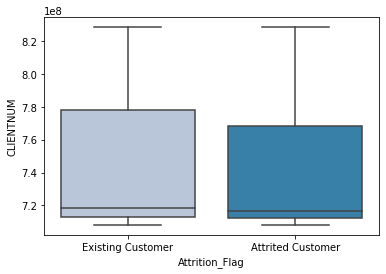

```python
sns.boxplot(data['Attrition_Flag'],data['CLIENTNUM'],palette="PuBu")
```

No difference. drop this as I think it is irrelavent

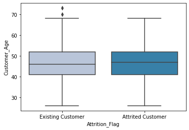

```python
sns.boxplot(data['Attrition_Flag'],data['Customer_Age'],palette="PuBu")
```

Very close, outliers in existing

```
Attrition_Flag  Attrited Customer  Existing Customer    All
Gender
All                          1627               8500  10127
F                             930               4428   5358
M                             697               4072   4769
------------------------------------------------------------------------------------------------------------------------
```

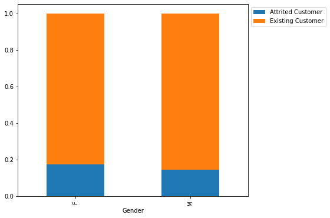

```python
stacked_barplot(data, "Gender","Attrition_Flag")
```

Female slighly more liekly to leave

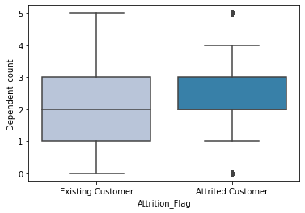

```python
sns.boxplot(data['Attrition_Flag'],data['Dependent_count'],palette="PuBu")
```

Attrited is higher than existing though overlap is there

```
Attrition_Flag   Attrited Customer  Existing Customer   All
Education_Level
All                           1371               7237  8608
Graduate                       487               2641  3128
High School                    306               1707  2013
Uneducated                     237               1250  1487
College                        154                859  1013
Doctorate                       95                356   451
Post-Graduate                   92                424   516
------------------------------------------------------------------------------------------------------------------------
```

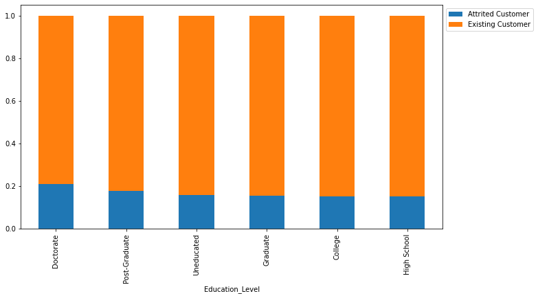

```python
stacked_barplot(data, "Education_Level","Attrition_Flag")
```

Doctorate, post grad and uneducated all pretty high. others lowers

```
Attrition_Flag  Attrited Customer  Existing Customer   All
Marital_Status
All                          1498               7880  9378
Married                       709               3978  4687
Single                        668               3275  3943
Divorced                      121                627   748
------------------------------------------------------------------------------------------------------------------------
```

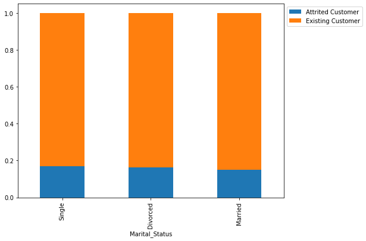

```python
stacked_barplot(data, "Marital_Status","Attrition_Flag")
```

single higher than divorced which is higher than married, by a little each time

```
Attrition_Flag   Attrited Customer  Existing Customer    All
Income_Category
All                           1627               8500  10127
Less than $40K                 799               3874   4673
$40K - $60K                    271               1519   1790
$80K - $120K                   242               1293   1535
$60K - $80K                    189               1213   1402
$120K +                        126                601    727
------------------------------------------------------------------------------------------------------------------------
```

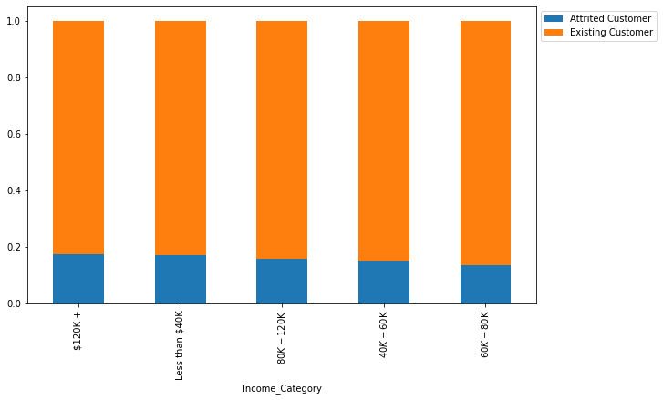

```python
stacked_barplot(data, "Income_Category","Attrition_Flag")
```

120 is suprisingly high, 60-80 low

```
Attrition_Flag  Attrited Customer  Existing Customer    All
Card_Category
All                          1627               8500  10127
Blue                         1519               7917   9436
Silver                         82                473    555
Gold                           21                 95    116
Platinum                        5                 15     20
------------------------------------------------------------------------------------------------------------------------
```

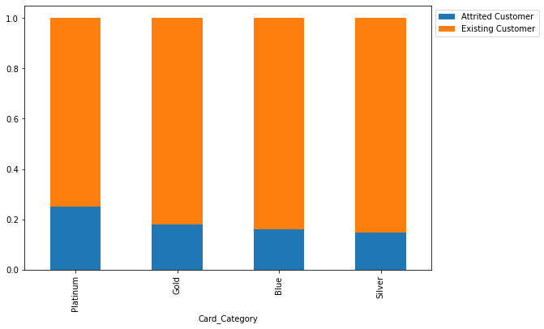

```python
stacked_barplot(data, "Card_Category","Attrition_Flag")
```

Platinum is high

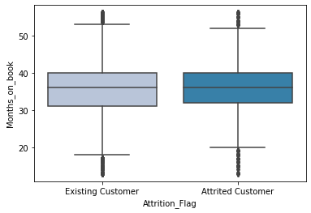

```python
sns.boxplot(data['Attrition_Flag'],data['Months_on_book'],palette="PuBu")
```

Very close

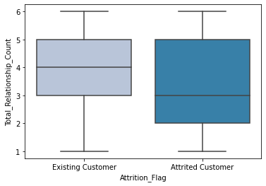

```python
sns.boxplot(data['Attrition_Flag'],data['Total_Relationship_Count'],palette="PuBu")
```

Existing is higher

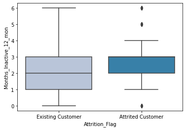

```python
sns.boxplot(data['Attrition_Flag'],data['Months_Inactive_12_mon'],palette="PuBu")
```

Existing is lower

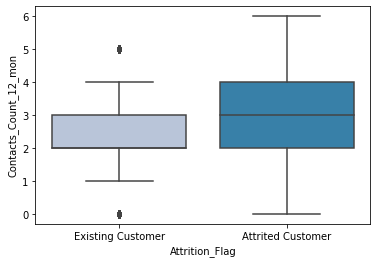

```python
sns.boxplot(data['Attrition_Flag'],data['Contacts_Count_12_mon'],palette="PuBu")
```

Existing lower

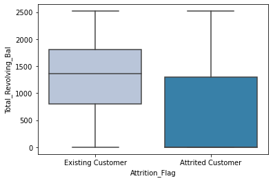

```python
sns.boxplot(data['Attrition_Flag'],data['Total_Revolving_Bal'],palette="PuBu")
```

Existing higher

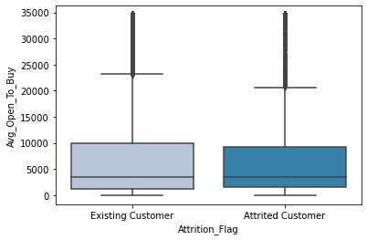

```python
sns.boxplot(data['Attrition_Flag'],data['Avg_Open_To_Buy'],palette="PuBu")
```

No real difference

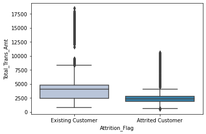

```python
sns.boxplot(data['Attrition_Flag'],data['Total_Trans_Amt'],palette="PuBu")
```

Existing is higher

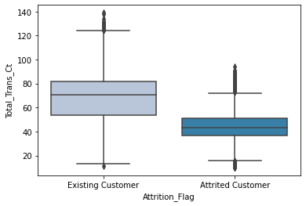

```python
sns.boxplot(data['Attrition_Flag'],data['Total_Trans_Ct'],palette="PuBu")
```

Existing is higher

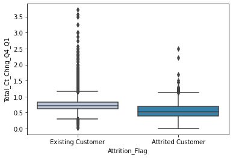

```python
sns.boxplot(data['Attrition_Flag'],data['Total_Ct_Chng_Q4_Q1'],palette="PuBu")
```

Existing is slighyl higherZ

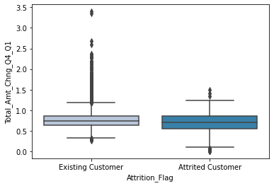

```python
sns.boxplot(data['Attrition_Flag'],data['Total_Amt_Chng_Q4_Q1'],palette="PuBu")
```

Existing very slightly higher

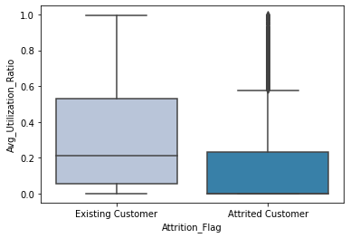

```python
sns.boxplot(data['Attrition_Flag'],data['Avg_Utilization_Ratio'],palette="PuBu")
```

Existing is higher

Key take aways

Uni Skewed:Dependent_Countm Months_Inactive_12_mon, Contacts_Count_12_mon, Credit_Limit, Avg_Open_To_Buy, Avg_Utilization_Ratio Outlier: Total_Revolving_Bal, Total_Ct_Chng_Q4_Q1 Multipeaked: Total_Trans_Amt Imbalanced: most cards were blue and most incomes below 40k, high number of grad or higher educations Most people have little momney with us and spend little. Most like the blue card and are atleast graduate educated

Bi Gender: female more likely to be attrited, I think any bias here would be illegal so don't pay too much attention Dependent_count: those thatare attrited tend to have more dependents, look for those with smaller families Education_Level: doctorate, post grad, and uneducated have higher atrition. Focus oin those in between Marital_Status: single higher than divorced and both are higher than arried in terms of attition, watch out for thoose who aren't married Income_Category: those thank make upwartds of 120k are more like to atrited, focus ont hoise making leess especiually 60-80k Card_Category: platinum more lokely top attrite, focus on less premium cards

Data pre-processing

- Prepare the data for analysis - Feature Engineering - Missing value Treatment - Outlier Treatment Note: Please ensure no data leakage occurs among train-test and validation sets

Missing values

```python
data.isnull().sum().sort_values(ascending=False)
```

```
Education_Level             1519
Marital_Status               749
CLIENTNUM                      0
Months_Inactive_12_mon         0
Total_Ct_Chng_Q4_Q1            0
Total_Trans_Ct                 0
Total_Trans_Amt                0
Total_Amt_Chng_Q4_Q1           0
Avg_Open_To_Buy                0
Total_Revolving_Bal            0
Contacts_Count_12_mon          0
Total_Relationship_Count       0
Attrition_Flag                 0
Months_on_book                 0
Card_Category                  0
Income_Category                0
Dependent_count                0
Gender                         0
Customer_Age                   0
Avg_Utilization_Ratio          0
dtype: int64
```

replace missing

```python
data['Education_Level'].fillna("Graduate",inplace=True)
data['Education_Level'].isnull().sum()
```

```
0
```

```python
data['Marital_Status'].fillna("Married",inplace=True)
data['Marital_Status'].isnull().sum()
```

```
0
```

Make dummies

```python
y=data['Attrition_Flag']
data.drop(['Attrition_Flag'], axis=1, inplace=True)
data = pd.get_dummies(
    data,
    columns=data.select_dtypes(include=["object", "category"]).columns.tolist(),
    drop_first=True,
)
```

```python
data.head()
```

|  | CLIENTNUM | Customer_Age | Dependent_count | Months_on_book | Total_Relationship_Count | Months_Inactive_12_mon | Contacts_Count_12_mon | Total_Revolving_Bal | Avg_Open_To_Buy | Total_Amt_Chng_Q4_Q1 | ... | Education_Level_Uneducated | Marital_Status_Married | Marital_Status_Single | Income_Category_$40K - $60K | Income_Category_$60K - $80K | Income_Category_$80K - $120K | Income_Category_Less than $40K | Card_Category_Gold | Card_Category_Platinum | Card_Category_Silver |
| --- | --- | --- | --- | --- | --- | --- | --- | --- | --- | --- | --- | --- | --- | --- | --- | --- | --- | --- | --- | --- | --- |
| 0 | 768805383 | 45 | 3 | 39 | 5 | 1 | 3 | 777 | 11914.0 | 1.335 | ... | 0 | 1 | 0 | 0 | 1 | 0 | 0 | 0 | 0 | 0 |
| 1 | 818770008 | 49 | 5 | 44 | 6 | 1 | 2 | 864 | 7392.0 | 1.541 | ... | 0 | 0 | 1 | 0 | 0 | 0 | 1 | 0 | 0 | 0 |
| 2 | 713982108 | 51 | 3 | 36 | 4 | 1 | 0 | 0 | 3418.0 | 2.594 | ... | 0 | 1 | 0 | 0 | 0 | 1 | 0 | 0 | 0 | 0 |
| 3 | 769911858 | 40 | 4 | 34 | 3 | 4 | 1 | 2517 | 796.0 | 1.405 | ... | 0 | 1 | 0 | 0 | 0 | 0 | 1 | 0 | 0 | 0 |
| 4 | 709106358 | 40 | 3 | 21 | 5 | 1 | 0 | 0 | 4716.0 | 2.175 | ... | 1 | 1 | 0 | 0 | 1 | 0 | 0 | 0 | 0 | 0 |

5 rows × 29 columns

```python
data['Attrition_Flag']=y
data.head()
```

|  | CLIENTNUM | Customer_Age | Dependent_count | Months_on_book | Total_Relationship_Count | Months_Inactive_12_mon | Contacts_Count_12_mon | Total_Revolving_Bal | Avg_Open_To_Buy | Total_Amt_Chng_Q4_Q1 | ... | Marital_Status_Married | Marital_Status_Single | Income_Category_$40K - $60K | Income_Category_$60K - $80K | Income_Category_$80K - $120K | Income_Category_Less than $40K | Card_Category_Gold | Card_Category_Platinum | Card_Category_Silver | Attrition_Flag |
| --- | --- | --- | --- | --- | --- | --- | --- | --- | --- | --- | --- | --- | --- | --- | --- | --- | --- | --- | --- | --- | --- |
| 0 | 768805383 | 45 | 3 | 39 | 5 | 1 | 3 | 777 | 11914.0 | 1.335 | ... | 1 | 0 | 0 | 1 | 0 | 0 | 0 | 0 | 0 | Existing Customer |
| 1 | 818770008 | 49 | 5 | 44 | 6 | 1 | 2 | 864 | 7392.0 | 1.541 | ... | 0 | 1 | 0 | 0 | 0 | 1 | 0 | 0 | 0 | Existing Customer |
| 2 | 713982108 | 51 | 3 | 36 | 4 | 1 | 0 | 0 | 3418.0 | 2.594 | ... | 1 | 0 | 0 | 0 | 1 | 0 | 0 | 0 | 0 | Existing Customer |
| 3 | 769911858 | 40 | 4 | 34 | 3 | 4 | 1 | 2517 | 796.0 | 1.405 | ... | 1 | 0 | 0 | 0 | 0 | 1 | 0 | 0 | 0 | Existing Customer |
| 4 | 709106358 | 40 | 3 | 21 | 5 | 1 | 0 | 0 | 4716.0 | 2.175 | ... | 1 | 0 | 0 | 1 | 0 | 0 | 0 | 0 | 0 | Existing Customer |

5 rows × 30 columns

Forgot to drop CLIENTNUM, i will fix now

```python
data.drop(['CLIENTNUM'], axis=1, inplace=True)
```

```python
data.head()
```

|  | Customer_Age | Dependent_count | Months_on_book | Total_Relationship_Count | Months_Inactive_12_mon | Contacts_Count_12_mon | Total_Revolving_Bal | Avg_Open_To_Buy | Total_Amt_Chng_Q4_Q1 | Total_Trans_Amt | ... | Marital_Status_Married | Marital_Status_Single | Income_Category_$40K - $60K | Income_Category_$60K - $80K | Income_Category_$80K - $120K | Income_Category_Less than $40K | Card_Category_Gold | Card_Category_Platinum | Card_Category_Silver | Attrition_Flag |
| --- | --- | --- | --- | --- | --- | --- | --- | --- | --- | --- | --- | --- | --- | --- | --- | --- | --- | --- | --- | --- | --- |
| 0 | 45 | 3 | 39 | 5 | 1 | 3 | 777 | 11914.0 | 1.335 | 1144 | ... | 1 | 0 | 0 | 1 | 0 | 0 | 0 | 0 | 0 | Existing Customer |
| 1 | 49 | 5 | 44 | 6 | 1 | 2 | 864 | 7392.0 | 1.541 | 1291 | ... | 0 | 1 | 0 | 0 | 0 | 1 | 0 | 0 | 0 | Existing Customer |
| 2 | 51 | 3 | 36 | 4 | 1 | 0 | 0 | 3418.0 | 2.594 | 1887 | ... | 1 | 0 | 0 | 0 | 1 | 0 | 0 | 0 | 0 | Existing Customer |
| 3 | 40 | 4 | 34 | 3 | 4 | 1 | 2517 | 796.0 | 1.405 | 1171 | ... | 1 | 0 | 0 | 0 | 0 | 1 | 0 | 0 | 0 | Existing Customer |
| 4 | 40 | 3 | 21 | 5 | 1 | 0 | 0 | 4716.0 | 2.175 | 816 | ... | 1 | 0 | 0 | 1 | 0 | 0 | 0 | 0 | 0 | Existing Customer |

5 rows × 29 columns

Skewed: Dependent_Countm Months_Inactive_12_mon, Contacts_Count_12_mon, Credit_Limit, Avg_Open_To_Buy, Avg_Utilization_Ratio Outlier: Total_Revolving_Bal, Total_Ct_Chng_Q4_Q1 Multipeaked: Total_Trans_Amt

```python
data['Dependent_count'].mean()
```

```
2.3462032191172115
```

```python
data['Dependent_count'].median()
```

```
2.0
```

Log this

```python
data['Months_Inactive_12_mon'].mean()
```

```
2.3411671768539546
```

```python
data['Months_Inactive_12_mon'].median()
```

```
2.0
```

Close but not close enough, log

```python
data['Contacts_Count_12_mon'].mean()
```

```
2.4553174681544387
```

```python
data['Contacts_Count_12_mon'].median()
```

```
2.0
```

log, close but still off

data['Credit_Limit'] was removed

```python
data['Avg_Open_To_Buy'].mean()
```

```
7469.139636614887
```

```python
data['Avg_Open_To_Buy'].median()
```

```
3474.0
```

way off, log this

```python
data['Avg_Utilization_Ratio'].mean()
```

```
0.2748935518909845
```

```python
data['Avg_Utilization_Ratio'].median()
```

```
0.176
```

Little off, log this

```python
data['Total_Revolving_Bal'].mean()
```

```
1162.8140614199665
```

```python
data['Total_Revolving_Bal'].median()
```

```
1276.0
```

about 10% off,still log

```python
data['Total_Ct_Chng_Q4_Q1'].mean()
```

```
0.7122223758269962
```

```python
data['Total_Ct_Chng_Q4_Q1'].median()
```

```
0.702
```

Really close, don't log

```python
data['Total_Trans_Amt'].mean()
```

```
4404.086303939963
```

```python
data['Total_Trans_Amt'].median()
```

```
3899.0
```

A little off, log

```python
cols_to_log = ['Dependent_count','Months_Inactive_12_mon', 'Contacts_Count_12_mon','Avg_Open_To_Buy','Avg_Utilization_Ratio','Total_Revolving_Bal','Total_Trans_Amt']
for colname in cols_to_log:
    data[colname + '_log'] = np.log(data[colname] + 1)
data.drop(cols_to_log, axis=1, inplace=True)
data
```

|  | Customer_Age | Months_on_book | Total_Relationship_Count | Total_Amt_Chng_Q4_Q1 | Total_Trans_Ct | Total_Ct_Chng_Q4_Q1 | Gender_M | Education_Level_Doctorate | Education_Level_Graduate | Education_Level_High School | ... | Card_Category_Platinum | Card_Category_Silver | Attrition_Flag | Dependent_count_log | Months_Inactive_12_mon_log | Contacts_Count_12_mon_log | Avg_Open_To_Buy_log | Avg_Utilization_Ratio_log | Total_Revolving_Bal_log | Total_Trans_Amt_log |
| --- | --- | --- | --- | --- | --- | --- | --- | --- | --- | --- | --- | --- | --- | --- | --- | --- | --- | --- | --- | --- | --- |
| 0 | 45 | 39 | 5 | 1.335 | 42 | 1.625 | 1 | 0 | 0 | 1 | ... | 0 | 0 | Existing Customer | 1.386294 | 0.693147 | 1.386294 | 9.385553 | 0.059212 | 6.656727 | 7.043160 |
| 1 | 49 | 44 | 6 | 1.541 | 33 | 3.714 | 0 | 0 | 1 | 0 | ... | 0 | 0 | Existing Customer | 1.791759 | 0.693147 | 1.098612 | 8.908289 | 0.099845 | 6.762730 | 7.163947 |
| 2 | 51 | 36 | 4 | 2.594 | 20 | 2.333 | 1 | 0 | 1 | 0 | ... | 0 | 0 | Existing Customer | 1.386294 | 0.693147 | 0.000000 | 8.137103 | 0.000000 | 0.000000 | 7.543273 |
| 3 | 40 | 34 | 3 | 1.405 | 20 | 2.333 | 0 | 0 | 0 | 1 | ... | 0 | 0 | Existing Customer | 1.609438 | 1.609438 | 0.693147 | 6.680855 | 0.565314 | 7.831220 | 7.066467 |
| 4 | 40 | 21 | 5 | 2.175 | 28 | 2.500 | 1 | 0 | 0 | 0 | ... | 0 | 0 | Existing Customer | 1.386294 | 0.693147 | 0.000000 | 8.458928 | 0.000000 | 0.000000 | 6.705639 |
| ... | ... | ... | ... | ... | ... | ... | ... | ... | ... | ... | ... | ... | ... | ... | ... | ... | ... | ... | ... | ... | ... |
| 10122 | 50 | 40 | 3 | 0.703 | 117 | 0.857 | 1 | 0 | 1 | 0 | ... | 0 | 0 | Existing Customer | 1.098612 | 1.098612 | 1.386294 | 7.674617 | 0.379805 | 7.524021 | 9.647110 |
| 10123 | 41 | 25 | 4 | 0.804 | 69 | 0.683 | 1 | 0 | 1 | 0 | ... | 0 | 0 | Attrited Customer | 1.098612 | 1.098612 | 1.386294 | 7.645876 | 0.412772 | 7.690286 | 9.078522 |
| 10124 | 44 | 36 | 5 | 0.819 | 60 | 0.818 | 0 | 0 | 0 | 1 | ... | 0 | 0 | Attrited Customer | 0.693147 | 1.386294 | 1.609438 | 8.596004 | 0.000000 | 0.000000 | 9.239122 |
| 10125 | 30 | 36 | 4 | 0.535 | 62 | 0.722 | 1 | 0 | 1 | 0 | ... | 0 | 0 | Attrited Customer | 1.098612 | 1.386294 | 1.386294 | 8.572060 | 0.000000 | 0.000000 | 9.035511 |
| 10126 | 43 | 25 | 6 | 0.703 | 61 | 0.649 | 0 | 0 | 1 | 0 | ... | 0 | 1 | Attrited Customer | 1.098612 | 1.098612 | 1.609438 | 9.039315 | 0.173113 | 7.581720 | 9.239414 |

10127 rows × 29 columns

```python
data['Dependent_count_log'].mean()
```

```
1.11297893038281
```

```python
data['Dependent_count_log'].median()
```

```
1.0986122886681098
```

```python
data['Months_Inactive_12_mon_log'].mean()
```

```
1.1598166124598632
```

```python
data['Months_Inactive_12_mon_log'].median()
```

```
1.0986122886681098
```

```python
data['Contacts_Count_12_mon_log'].mean()
```

```
1.1781071204224927
```

```python
data['Contacts_Count_12_mon_log'].median()
```

```
1.0986122886681098
```

```python
data['Avg_Open_To_Buy_log'].mean()
```

```
8.164538314637664
```

```python
data['Avg_Open_To_Buy_log'].median()
```

```
8.153349757998892
```

```python
data['Avg_Utilization_Ratio_log'].mean()
```

```
0.22091748202427622
```

```python
data['Avg_Utilization_Ratio_log'].median()
```

```
0.16211884947643512
```

This one is off still

```python
 data['Total_Revolving_Bal_log'].mean()
```

```
5.491204393083048
```

```python
 data['Total_Revolving_Bal_log'].median()
```

```
7.152268856032539
```

```python
data['Total_Trans_Amt_log'].mean()
```

```
8.165163993911522
```

```python
data['Total_Trans_Amt_log'].median()
```

```
8.268731832117737
```

Total_Revolving_Bal_log and Avg_Utilization_Ratio_log still off but otherwise we are doing well ZSCORE all numeric

```python
from sklearn.preprocessing import StandardScaler
std_scaler = StandardScaler()
cols_to_z_score=['Customer_Age','Months_on_book','Total_Relationship_Count','Total_Amt_Chng_Q4_Q1','Total_Trans_Ct','Total_Ct_Chng_Q4_Q1','Dependent_count_log','Months_Inactive_12_mon_log','Contacts_Count_12_mon_log','Avg_Open_To_Buy_log','Avg_Utilization_Ratio_log','Total_Revolving_Bal_log','Total_Trans_Amt_log']


for colname in cols_to_z_score:
    data[colname]=std_scaler.fit_transform(data[[colname]])
```

Split

```python
clean_up={"Attrition_Flag":{"Existing Customer":1, "Attrited Customer":0}}
data=data.replace(clean_up)
data
```

|  | Customer_Age | Months_on_book | Total_Relationship_Count | Total_Amt_Chng_Q4_Q1 | Total_Trans_Ct | Total_Ct_Chng_Q4_Q1 | Gender_M | Education_Level_Doctorate | Education_Level_Graduate | Education_Level_High School | ... | Card_Category_Platinum | Card_Category_Silver | Attrition_Flag | Dependent_count_log | Months_Inactive_12_mon_log | Contacts_Count_12_mon_log | Avg_Open_To_Buy_log | Avg_Utilization_Ratio_log | Total_Revolving_Bal_log | Total_Trans_Amt_log |
| --- | --- | --- | --- | --- | --- | --- | --- | --- | --- | --- | --- | --- | --- | --- | --- | --- | --- | --- | --- | --- | --- |
| 0 | -0.165406 | 0.384621 | 0.763943 | 2.623494 | -0.973895 | 3.834003 | 1 | 0 | 0 | 1 | ... | 0 | 0 | 1 | 0.582219 | -1.507461 | 0.553962 | 0.931878 | -0.783903 | 0.371202 | -1.715043 |
| 1 | 0.333570 | 1.010715 | 1.407306 | 3.563293 | -1.357340 | 12.608573 | 0 | 0 | 1 | 0 | ... | 0 | 0 | 1 | 1.445945 | -1.507461 | -0.211527 | 0.567630 | -0.586923 | 0.404962 | -1.530414 |
| 2 | 0.583058 | 0.008965 | 0.120579 | 8.367214 | -1.911206 | 6.807864 | 1 | 0 | 1 | 0 | ... | 0 | 0 | 1 | 0.582219 | -1.507461 | -3.134806 | -0.020938 | -1.070945 | -1.748867 | -0.950593 |
| 3 | -0.789126 | -0.241473 | -0.522785 | 2.942843 | -1.911206 | 6.807864 | 0 | 0 | 0 | 1 | ... | 0 | 0 | 1 | 1.057562 | 1.452391 | -1.290422 | -1.132347 | 1.669535 | 0.745260 | -1.679416 |
| 4 | -0.789126 | -1.869317 | 0.763943 | 6.455682 | -1.570365 | 7.509325 | 1 | 0 | 0 | 0 | ... | 0 | 0 | 1 | 0.582219 | -1.507461 | -3.134806 | 0.224678 | -1.070945 | -1.748867 | -2.230961 |
| ... | ... | ... | ... | ... | ... | ... | ... | ... | ... | ... | ... | ... | ... | ... | ... | ... | ... | ... | ... | ... | ... |
| 10122 | 0.458314 | 0.509840 | -0.522785 | -0.259771 | 2.221481 | 0.608119 | 1 | 0 | 1 | 0 | ... | 0 | 0 | 1 | -0.030604 | -0.197706 | 0.553962 | -0.373907 | 0.770243 | 0.647422 | 2.265233 |
| 10123 | -0.664382 | -1.368442 | 0.120579 | 0.201004 | 0.176440 | -0.122745 | 1 | 0 | 1 | 0 | ... | 0 | 0 | 0 | -0.030604 | -0.197706 | 0.553962 | -0.395843 | 0.930054 | 0.700375 | 1.396116 |
| 10124 | -0.290150 | 0.008965 | 0.763943 | 0.269436 | -0.207005 | 0.444305 | 0 | 0 | 0 | 1 | ... | 0 | 0 | 0 | -0.894330 | 0.731581 | 1.147721 | 0.329295 | -1.070945 | -1.748867 | 1.641602 |
| 10125 | -2.036565 | 0.008965 | 0.120579 | -1.026208 | -0.121795 | 0.041070 | 1 | 0 | 1 | 0 | ... | 0 | 0 | 0 | -0.030604 | 0.731581 | 0.553962 | 0.311021 | -1.070945 | -1.748867 | 1.330371 |
| 10126 | -0.414894 | -1.368442 | 1.407306 | -0.259771 | -0.164400 | -0.265557 | 0 | 0 | 1 | 0 | ... | 0 | 1 | 0 | -0.030604 | -0.197706 | 1.147721 | 0.667629 | -0.231744 | 0.665798 | 1.642047 |

10127 rows × 29 columns

```python
# separating the independent and dependent variables
X = data.drop(["Attrition_Flag"], axis=1)
y = data["Attrition_Flag"]
```

```python
# Splitting data into training, validation and test set:

# first we split data into 2 parts, say temporary and test
X_train, X_temp, y_train, y_temp = train_test_split(
    X, y, test_size=0.2, random_state=0, stratify=y
)

# then we split the temporary set into train and validation
X_val, X_test, y_val, y_test = train_test_split(
    X_temp, y_temp, test_size=0.3, random_state=0, stratify=y_temp
)

print(X_train.shape, X_val.shape, X_test.shape)
```

```
(8101, 28) (1418, 28) (608, 28)
```

Model building

- Choose metric on interest - Build 6 models (from logistic regression, decision trees, bagging and boosting methods) Note: You can choose not to build XGBoost if you are facing issues with the installation Metric of interest: recall, we want to see how to maintain customers

Decision tree

```python
from sklearn.tree import DecisionTreeClassifier
from sklearn import tree
def model_performance_classification_sklearn(model, predictors, target):
    """
    Function to compute different metrics to check classification model performance

    model: classifier
    predictors: independent variables
    target: dependent variable
    """

    # predicting using the independent variables
    pred = model.predict(predictors)

    acc = accuracy_score(target, pred)  # to compute Accuracy
    recall = recall_score(target, pred)  # to compute Recall
    precision = precision_score(target, pred)  # to compute Precision
    f1 = f1_score(target, pred)  # to compute F1-score

    # creating a dataframe of metrics
    df_perf = pd.DataFrame(
        {
            "Accuracy": acc,
            "Recall": recall,
            "Precision": precision,
            "F1": f1,
        },
        index=[0],
    )

    return df_perf
```

```python
def confusion_matrix_sklearn(model, predictors, target):
    """
    To plot the confusion_matrix with percentages

    model: classifier
    predictors: independent variables
    target: dependent variable
    """
    y_pred = model.predict(predictors)
    cm = confusion_matrix(target, y_pred)
    labels = np.asarray(
        [
            ["{0:0.0f}".format(item) + "\n{0:.2%}".format(item / cm.flatten().sum())]
            for item in cm.flatten()
        ]
    ).reshape(2, 2)

    plt.figure(figsize=(6, 4))
    sns.heatmap(cm, annot=labels, fmt="")
    plt.ylabel("True label")
    plt.xlabel("Predicted label")
```

```python
dTree = DecisionTreeClassifier(criterion = 'gini', random_state=1)
dTree.fit(X_train, y_train)
```

```
DecisionTreeClassifier(random_state=1)
```

```
Training performance:
    Accuracy  Recall  Precision   F1
0       1.0     1.0        1.0  1.0
Validation performance:
    Accuracy    Recall  Precision        F1
0   0.93653  0.968094   0.956846  0.962437
```

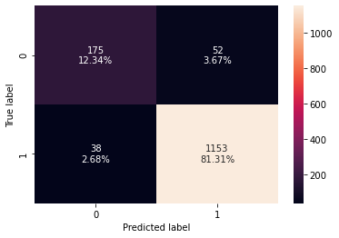

```python
#Calculating different metrics
dtree_model_train_perf=model_performance_classification_sklearn(dTree,X_train,y_train)
print("Training performance:\n",dtree_model_train_perf)
dtree_model_test_perf=model_performance_classification_sklearn(dTree,X_val,y_val)
print("Validation performance:\n",dtree_model_test_perf)
#Creating confusion matrix
confusion_matrix_sklearn(dTree, X_val, y_val)
```

really good

Logistic regression

```python
from sklearn import metrics

from sklearn.linear_model import LogisticRegression

# Fit the model on train
model = LogisticRegression(solver="liblinear", random_state=1)
model.fit(X_train, y_train)
#predict on test
```

```
LogisticRegression(random_state=1, solver='liblinear')
```

```
Training performance:
    Accuracy   Recall  Precision        F1
0  0.917664  0.96926   0.935017  0.951831
Validation performance:
    Accuracy    Recall  Precision        F1
0  0.909027  0.969773   0.925481  0.947109
```

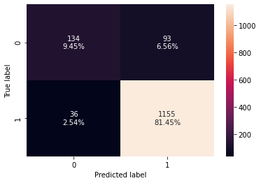

```python
lin_model_train_perf=model_performance_classification_sklearn(model,X_train,y_train)
print("Training performance:\n",lin_model_train_perf)
lin_model_test_perf=model_performance_classification_sklearn(model,X_val,y_val)
print("Validation performance:\n",lin_model_test_perf)
#Creating confusion matrix
confusion_matrix_sklearn(model, X_val, y_val)
```

A little better even

Random forest

```python
from sklearn.ensemble import BaggingClassifier, RandomForestClassifier
```

```python
#Train the random forest classifier
rf_estimator=RandomForestClassifier(random_state=1)
rf_estimator.fit(X_train,y_train)
```

```
RandomForestClassifier(random_state=1)
```

```
Training performance:
    Accuracy  Recall  Precision   F1
0       1.0     1.0        1.0  1.0
Validation performance:
    Accuracy    Recall  Precision        F1
0  0.954161  0.987406   0.959217  0.973107
```

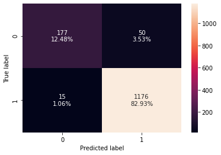

```python
rf_model_train_perf=model_performance_classification_sklearn(rf_estimator,X_train,y_train)
print("Training performance:\n",rf_model_train_perf)
rf_model_test_perf=model_performance_classification_sklearn(rf_estimator,X_val,y_val)
print("Validation performance:\n",rf_model_test_perf)
#Creating confusion matrix
confusion_matrix_sklearn(rf_estimator, X_val, y_val)
```

Higher even than last

Bagging= logistic regression

```python
bagging_lr=BaggingClassifier(base_estimator=LogisticRegression(solver='liblinear',random_state=1),random_state=1)
bagging_lr.fit(X_train,y_train)
```

```
BaggingClassifier(base_estimator=LogisticRegression(random_state=1,
                                                    solver='liblinear'),
                  random_state=1)
```

```
Training performance:
    Accuracy    Recall  Precision        F1
0  0.917664  0.969701   0.934647  0.951852
Validation performance:
    Accuracy    Recall  Precision        F1
0  0.908322  0.969773    0.92474  0.946721
```

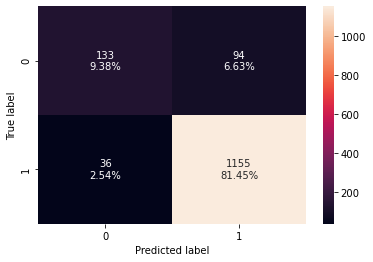

```python
bag_model_train_perf=model_performance_classification_sklearn(bagging_lr,X_train,y_train)
print("Training performance:\n",bag_model_train_perf)
bag_model_test_perf=model_performance_classification_sklearn(bagging_lr,X_val,y_val)
print("Validation performance:\n",bag_model_test_perf)
#Creating confusion matrix
confusion_matrix_sklearn(bagging_lr, X_val, y_val)
```

Same as logistic regression but with less overfitting

ADA boosting

```python
from sklearn.ensemble import AdaBoostClassifier, GradientBoostingClassifier
```

```python
abc = AdaBoostClassifier(random_state=1)
abc.fit(X_train,y_train)
```

```
AdaBoostClassifier(random_state=1)
```

```
Training performance:
    Accuracy    Recall  Precision        F1
0  0.962597  0.981762   0.973884  0.977807
Validation performance:
    Accuracy    Recall  Precision       F1
0  0.952045  0.979849   0.963666  0.97169
```

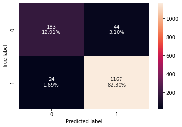

```python
abc_model_train_perf=model_performance_classification_sklearn(abc,X_train,y_train)
print("Training performance:\n",abc_model_train_perf)
abc_model_test_perf=model_performance_classification_sklearn(abc,X_val,y_val)
print("Validation performance:\n",abc_model_test_perf)
#Creating confusion matrix
confusion_matrix_sklearn(abc, X_val, y_val)
```

Second best behing rf

gradient boost

```python
gbc = GradientBoostingClassifier(random_state=1)
gbc.fit(X_train,y_train)
```

```
GradientBoostingClassifier(random_state=1)
```

```
Training performance:
    Accuracy    Recall  Precision        F1
0  0.974448  0.992499   0.977404  0.984894
Validation performance:
    Accuracy    Recall  Precision        F1
0  0.961213  0.989924   0.964812  0.977207
```

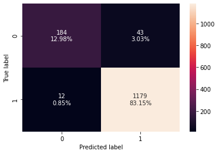

```python
gbc_model_train_perf=model_performance_classification_sklearn(gbc,X_train,y_train)
print("Training performance:\n",gbc_model_train_perf)
gbc_model_test_perf=model_performance_classification_sklearn(gbc,X_val,y_val)
print("Validation performance:\n",gbc_model_test_perf)
#Creating confusion matrix
confusion_matrix_sklearn(gbc, X_val, y_val)
```

Highest yet our top three so far Gradient boostin: validation recall is 0.989924 Random forest: validation recall is 0.987406 ADA boosting:: validation recall is 0.979849

Model building - Oversampled data Build 6 models using oversampled data (from logistic regression, decision trees, bagging and boosting methods) - You can choose not to build XGBoost if you are facing issues with the installation

D tree

```python
sm = SMOTE(sampling_strategy=0.4, k_neighbors=5, random_state=1)
X_train_over, y_train_over = sm.fit_resample(X_train, y_train)
```

```python
dTree1 = DecisionTreeClassifier(criterion = 'gini',random_state=1)

# training the decision tree model with oversampled training set
dTree1.fit(X_train_over, y_train_over)
```

```
DecisionTreeClassifier(random_state=1)
```

```
Training performance:
    Accuracy  Recall  Precision   F1
0       1.0     1.0        1.0  1.0
Validation performance:
    Accuracy    Recall  Precision        F1
0  0.928773  0.958018   0.957215  0.957616
```

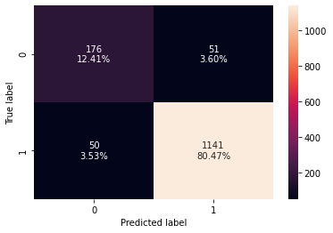

```python
#Calculating different metrics
dtree1_model_train_perf=model_performance_classification_sklearn(dTree1,X_train,y_train)
print("Training performance:\n",dtree1_model_train_perf)
dtree1_model_test_perf=model_performance_classification_sklearn(dTree1,X_val,y_val)
print("Validation performance:\n",dtree1_model_test_perf)
#Creating confusion matrix
confusion_matrix_sklearn(dTree1, X_val, y_val)
```

Worse than original

Logisticx regression

```python
model1 = LogisticRegression(solver="liblinear", random_state=1)
model1.fit(X_train_over, y_train_over)
```

```
LogisticRegression(random_state=1, solver='liblinear')
```

```
Training performance:
    Accuracy    Recall  Precision        F1
0  0.912727  0.948522   0.947546  0.948034
Validation performance:
    Accuracy    Recall  Precision        F1
0  0.906206  0.949622   0.939369  0.944468
```

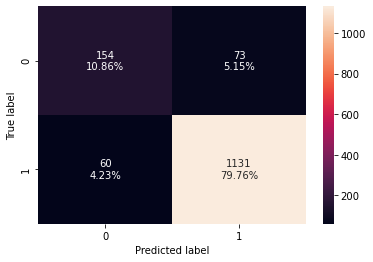

```python
lin1_model_train_perf=model_performance_classification_sklearn(model1,X_train,y_train)
print("Training performance:\n",lin1_model_train_perf)
lin1_model_test_perf=model_performance_classification_sklearn(model1,X_val,y_val)
print("Validation performance:\n",lin1_model_test_perf)
#Creating confusion matrix
confusion_matrix_sklearn(model1, X_val, y_val)
```

Worse than original

random forest

```python
#Train the random forest classifier
rf1_estimator=RandomForestClassifier(random_state=1)
rf1_estimator.fit(X_train_over,y_train_over)
```

```
RandomForestClassifier(random_state=1)
```

```
Training performance:
    Accuracy  Recall  Precision   F1
0       1.0     1.0        1.0  1.0
Validation performance:
    Accuracy    Recall  Precision        F1
0  0.958392  0.984887   0.966227  0.975468
```

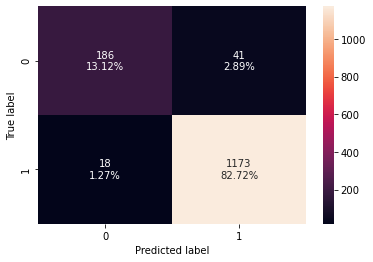

```python
rf1_model_train_perf=model_performance_classification_sklearn(rf1_estimator,X_train,y_train)
print("Training performance:\n",rf1_model_train_perf)
rf1_model_test_perf=model_performance_classification_sklearn(rf1_estimator,X_val,y_val)
print("Validation performance:\n",rf1_model_test_perf)
#Creating confusion matrix
confusion_matrix_sklearn(rf1_estimator, X_val, y_val)
```

Worse than orignal but better than ada boosting our top three so far Gradient boostin: validation recall is 0.989924 Random forest: validation recall is 0.987406 oversampled rf:: validation recall is 0.984887

Bging logistic reg

```python
bagging1_lr=BaggingClassifier(base_estimator=LogisticRegression(solver='liblinear',random_state=1),random_state=1)
bagging1_lr.fit(X_train_over,y_train_over)
```

```
BaggingClassifier(base_estimator=LogisticRegression(random_state=1,
                                                    solver='liblinear'),
                  random_state=1)
```

```
Training performance:
    Accuracy    Recall  Precision        F1
0  0.912233  0.948669   0.946858  0.947763
Validation performance:
    Accuracy    Recall  Precision        F1
0   0.90409  0.947103   0.939217  0.943144
```

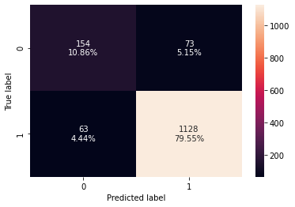

```python
bag1_model_train_perf=model_performance_classification_sklearn(bagging1_lr,X_train,y_train)
print("Training performance:\n",bag1_model_train_perf)
bag1_model_test_perf=model_performance_classification_sklearn(bagging1_lr,X_val,y_val)
print("Validation performance:\n",bag1_model_test_perf)
#Creating confusion matrix
confusion_matrix_sklearn(bagging1_lr, X_val, y_val)
```

Worse than orignal

ADA boosting

```python
abc1 = AdaBoostClassifier(random_state=1)
abc1.fit(X_train_over,y_train_over)
```

```
AdaBoostClassifier(random_state=1)
```

```
Training performance:
    Accuracy    Recall  Precision        F1
0  0.960622  0.972349    0.98057  0.976442
Validation performance:
    Accuracy    Recall  Precision       F1
0  0.949929  0.968094   0.972175  0.97013
```

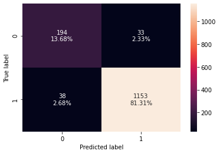

```python
abc1_model_train_perf=model_performance_classification_sklearn(abc1,X_train,y_train)
print("Training performance:\n",abc1_model_train_perf)
abc1_model_test_perf=model_performance_classification_sklearn(abc1,X_val,y_val)
print("Validation performance:\n",abc1_model_test_perf)
#Creating confusion matrix
confusion_matrix_sklearn(abc1, X_val, y_val)
```

Again, worse and does no beet any of the tops

Gradient boosting

```python
gbc1= GradientBoostingClassifier(random_state=1)
gbc1.fit(X_train_over,y_train_over)
```

```
GradientBoostingClassifier(random_state=1)
```

```
Training performance:
    Accuracy    Recall  Precision        F1
0  0.973584  0.985586   0.982984  0.984283
Validation performance:
    Accuracy    Recall  Precision        F1
0  0.970381  0.989085   0.975973  0.982485
```

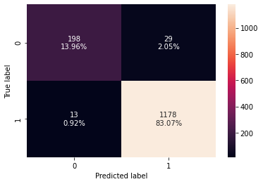

```python
gbc1_model_train_perf=model_performance_classification_sklearn(gbc1,X_train,y_train)
print("Training performance:\n",gbc1_model_train_perf)
gbc1_model_test_perf=model_performance_classification_sklearn(gbc1,X_val,y_val)
print("Validation performance:\n",gbc1_model_test_perf)
#Creating confusion matrix
confusion_matrix_sklearn(gbc1, X_val, y_val)
```

Worse than orignal but better than two and three on our list our top three so far Gradient boostin: validation recall is 0.989924 Oversamples gradient boosting: validation recall is 0.989085 Random forest: validation recall is 0.987406

Model building - Undersampled data Build 6 models using undersampled data(from logistic regression, decision trees, bagging and boosting methods) - You can choose not to build XGBoost if you are facing issues with installation

Decision tree

```python
# fit random under sampler on the train data
rus = RandomUnderSampler(random_state=1, sampling_strategy = 1)
X_train_un, y_train_un = rus.fit_resample(X_train, y_train)
```

```python
dTree2 = DecisionTreeClassifier(criterion = 'gini',random_state=1)

# training the decision tree model with oversampled training set
dTree2.fit(X_train_un, y_train_un)
```

```
DecisionTreeClassifier(random_state=1)
```

```
Training performance:
    Accuracy    Recall  Precision       F1
0  0.937539  0.925577        1.0  0.96135
Validation performance:
    Accuracy    Recall  Precision        F1
0  0.910437  0.919395   0.972469  0.945188
```

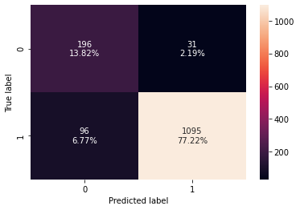

```python
#Calculating different metrics
dtree2_model_train_perf=model_performance_classification_sklearn(dTree2,X_train,y_train)
print("Training performance:\n",dtree2_model_train_perf)
dtree2_model_test_perf=model_performance_classification_sklearn(dTree2,X_val,y_val)
print("Validation performance:\n",dtree2_model_test_perf)
#Creating confusion matrix
confusion_matrix_sklearn(dTree2, X_val, y_val)
```

worse than regular or over

logistic regressuion

```python
model2 = LogisticRegression(solver="liblinear", random_state=1)
model2.fit(X_train_un, y_train_un)
```

```
LogisticRegression(random_state=1, solver='liblinear')
```

```
Training performance:
    Accuracy    Recall  Precision        F1
0  0.865819  0.864539   0.972535  0.915362
Validation performance:
    Accuracy    Recall  Precision        F1
0   0.85543  0.857263   0.966856  0.908767
```

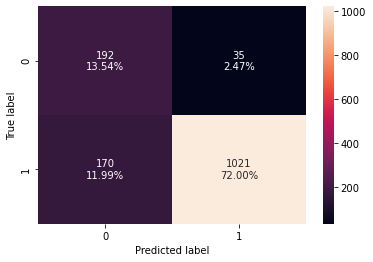

```python
lin2_model_train_perf=model_performance_classification_sklearn(model2,X_train,y_train)
print("Training performance:\n",lin2_model_train_perf)
lin2_model_test_perf=model_performance_classification_sklearn(model2,X_val,y_val)
print("Validation performance:\n",lin2_model_test_perf)
#Creating confusion matrix
confusion_matrix_sklearn(model2, X_val, y_val)
```

worse than regular or over

```python
rf2_estimator=RandomForestClassifier(random_state=1)
rf2_estimator.fit(X_train_over,y_train_over)
```

```
RandomForestClassifier(random_state=1)
```

```
Training performance:
    Accuracy  Recall  Precision   F1
0       1.0     1.0        1.0  1.0
Validation performance:
    Accuracy    Recall  Precision        F1
0  0.958392  0.984887   0.966227  0.975468
```

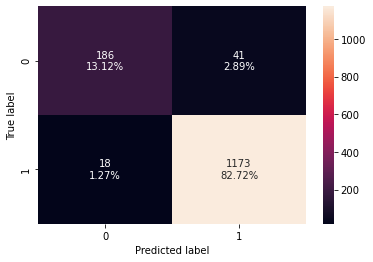

```python
rf2_model_train_perf=model_performance_classification_sklearn(rf2_estimator,X_train,y_train)
print("Training performance:\n",rf2_model_train_perf)
rf2_model_test_perf=model_performance_classification_sklearn(rf2_estimator,X_val,y_val)
print("Validation performance:\n",rf2_model_test_perf)
#Creating confusion matrix
confusion_matrix_sklearn(rf2_estimator, X_val, y_val)
```

logistic bagging

```python
bagging2_lr=BaggingClassifier(base_estimator=LogisticRegression(solver='liblinear',random_state=1),random_state=1)
bagging2_lr.fit(X_train_un,y_train_un)
```

```
BaggingClassifier(base_estimator=LogisticRegression(random_state=1,
                                                    solver='liblinear'),
                  random_state=1)
```

```
Training performance:
    Accuracy   Recall  Precision        F1
0  0.866807  0.86498   0.973353  0.915972
Validation performance:
    Accuracy    Recall  Precision        F1
0  0.853315  0.853904    0.96765  0.907226
```

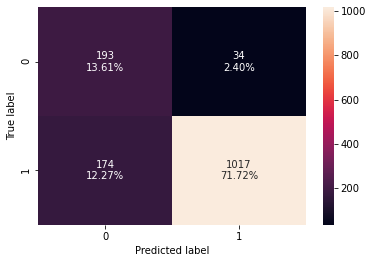

```python
bag2_model_train_perf=model_performance_classification_sklearn(bagging2_lr,X_train,y_train)
print("Training performance:\n",bag2_model_train_perf)
bag2_model_test_perf=model_performance_classification_sklearn(bagging2_lr,X_val,y_val)
print("Validation performance:\n",bag2_model_test_perf)
#Creating confusion matrix
confusion_matrix_sklearn(bagging2_lr, X_val, y_val)
```

again worse than base or over

ADA boosting

```python
abc2 = AdaBoostClassifier(random_state=1)
abc2.fit(X_train_un,y_train_un)
```

```
AdaBoostClassifier(random_state=1)
```

```
Training performance:
    Accuracy    Recall  Precision       F1
0  0.940995  0.937785   0.991448  0.96387
Validation performance:
    Accuracy    Recall  Precision        F1
0  0.926657  0.928631   0.983111  0.955095
```

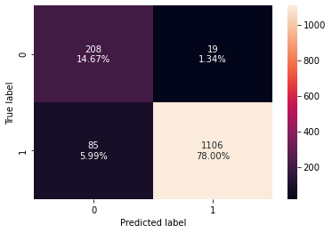

```python
abc2_model_train_perf=model_performance_classification_sklearn(abc2,X_train,y_train)
print("Training performance:\n",abc2_model_train_perf)
abc2_model_test_perf=model_performance_classification_sklearn(abc2,X_val,y_val)
print("Validation performance:\n",abc2_model_test_perf)
#Creating confusion matrix
confusion_matrix_sklearn(abc2, X_val, y_val)
```

again worse than base or over

Gradient boosting

```python
gbc2= GradientBoostingClassifier(random_state=1)
gbc2.fit(X_train_un,y_train_un)
```

```
GradientBoostingClassifier(random_state=1)
```

```
Training performance:
    Accuracy    Recall  Precision        F1
0  0.954327  0.949404   0.995988  0.972139
Validation performance:
    Accuracy    Recall  Precision        F1
0  0.943583  0.945424   0.986854  0.965695
```

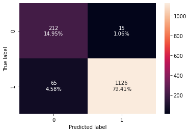

```python
gbc2_model_train_perf=model_performance_classification_sklearn(gbc2,X_train,y_train)
print("Training performance:\n",gbc2_model_train_perf)
gbc2_model_test_perf=model_performance_classification_sklearn(gbc2,X_val,y_val)
print("Validation performance:\n",gbc2_model_test_perf)
#Creating confusion matrix
confusion_matrix_sklearn(gbc2, X_val, y_val)
```

None of these displace previous top three

our top three so far Gradient boostin: validation recall is 0.989924 Oversamples gradient boosting: validation recall is 0.989085 Random forest: validation recall is 0.987406

Choose to tune 3 models

- Choose models that might perform better after tuning (tune at least 3 models out of 18 built in the previous steps) - Provide proper reasoning for tuning that model

It would be a good idea to tune any of these, but random forest, boosting, and bagging are all great choices as they tend to do better when tuned Addiitonally our tope three were gradient boosting (normal), over samples gradient boosting, and normal random forest so I will tune these three

Hyperparameter tuning using random search

- Tune the best 3 models obtained above using randomized search and metric of interest - Check the performance of 3 tuned models

Gradient boosting

```python
from sklearn.model_selection import GridSearchCV, RandomizedSearchCV
parameters = {
    "n_estimators": [100,150,200,250],
    "subsample":[0.8,0.9,1],
    "max_features":[0.7,0.8,0.9,1]
}
acc_scorer = metrics.make_scorer(metrics.recall_score)
grid_obj = RandomizedSearchCV(gbc, parameters,n_iter=30, scoring=acc_scorer,cv=5, random_state = 1, n_jobs = -1, verbose = 2)
grid_obj = grid_obj.fit(X_train, y_train)
gbc_tuned = grid_obj.best_estimator_

gbc_tuned.fit(X_train, y_train)
```

```
Fitting 5 folds for each of 30 candidates, totalling 150 fits
```

```
GradientBoostingClassifier(max_features=1, random_state=1, subsample=0.8)
```

[output not shown]

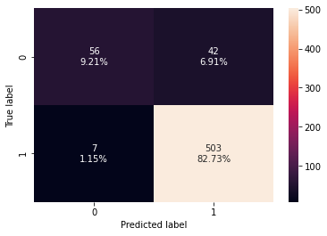

```python
gbct_model_train_perf=model_performance_classification_sklearn(gbc_tuned,X_train,y_train)
print("Training performance:\n",gbct_model_train_perf)
gbct_model_val_perf=model_performance_classification_sklearn(gbc_tuned,X_val,y_val)
print("Validation performance:\n",gbct_model_val_perf)
gbct_model_test_perf=model_performance_classification_sklearn(gbc_tuned,X_test,y_test)
print("Test performance:\n",gbct_model_val_perf)
#Creating confusion matrix
confusion_matrix_sklearn(gbc_tuned, X_test, y_test)
```

Over sampled gradient boosting

```python
grid_obj2 = RandomizedSearchCV(gbc1, parameters,n_iter=30, scoring=acc_scorer,cv=5, random_state = 1, n_jobs = -1, verbose = 2)
grid_obj2 = grid_obj.fit(X_train_over, y_train_over)
gbc_tuned2 = grid_obj2.best_estimator_
gbc_tuned2.fit(X_train_over, y_train_over)
```

```
Fitting 5 folds for each of 30 candidates, totalling 150 fits
```

```
GradientBoostingClassifier(max_features=0.8, n_estimators=250, random_state=1,
                           subsample=0.8)
```

[output not shown]

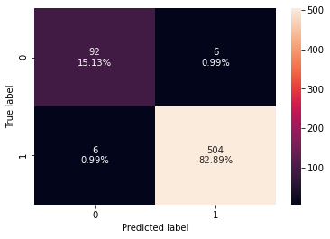

```python
gbct1_model_train_perf=model_performance_classification_sklearn(gbc_tuned2,X_train,y_train)
print("Training performance:\n",gbct1_model_train_perf)
gbct1_model_val_perf=model_performance_classification_sklearn(gbc_tuned2,X_val,y_val)
print("Validation performance:\n",gbct1_model_val_perf)
gbct1_model_test_perf=model_performance_classification_sklearn(gbc_tuned2,X_test,y_test)
print("Test performance:\n",gbct1_model_val_perf)
#Creating confusion matrix
confusion_matrix_sklearn(gbc_tuned2, X_test, y_test)
```

randoom forest

```python
parameters2 = {"n_estimators": [150,200,250],
    "min_samples_leaf": np.arange(5, 10),
    "max_features": np.arange(0.2, 0.7, 0.1),
    "max_samples": np.arange(0.3, 0.7, 0.1),
    "class_weight" : ['balanced', 'balanced_subsample'],
    "max_depth":np.arange(3,4,5),
    "min_impurity_decrease":[0.001, 0.002, 0.003]
             }
rf_estimator
grid_obj3 = RandomizedSearchCV(rf_estimator, parameters2,n_iter=30, scoring=acc_scorer,cv=5, random_state = 1, n_jobs = -1, verbose = 2)
grid_obj3 = grid_obj3.fit(X_train, y_train)
rf_tuned = grid_obj3.best_estimator_

rf_tuned.fit(X_train, y_train)
```

```
Fitting 5 folds for each of 30 candidates, totalling 150 fits
```

```
RandomForestClassifier(class_weight='balanced', max_depth=3, max_features=0.2,
                       max_samples=0.4, min_impurity_decrease=0.001,
                       min_samples_leaf=6, n_estimators=150, random_state=1)
```

```
Training performance:
    Accuracy    Recall  Precision        F1
0  0.869399  0.874246   0.966976  0.918276
Validation performance:
    Accuracy    Recall  Precision        F1
0  0.863893  0.870697   0.963755  0.914865
Test performance:
    Accuracy    Recall  Precision      F1
0  0.873355  0.876471   0.969631  0.9207
```

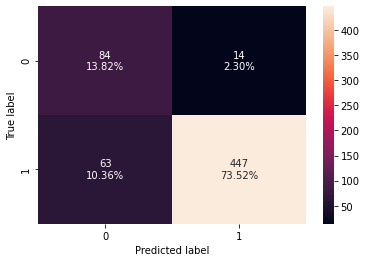

```python
rft_model_train_perf=model_performance_classification_sklearn(rf_tuned,X_train,y_train)
print("Training performance:\n",rft_model_train_perf)
rft_model_val_perf=model_performance_classification_sklearn(rf_tuned,X_val,y_val)
print("Validation performance:\n",rft_model_val_perf)
rft_model_test_perf=model_performance_classification_sklearn(rf_tuned,X_test,y_test)
print("Test performance:\n",rft_model_test_perf)
#Creating confusion matrix
confusion_matrix_sklearn(rf_tuned, X_test, y_test)
```

Model Performances

- Compare the model performance of tuned models - Choose the best model

Gradient boosting (noirmal) had the best test recall at 0.989924 Let's look at the paramaters and importance matrix

```python
grid_obj.best_params_
```

```
{'subsample': 0.8, 'n_estimators': 250, 'max_features': 0.8}
```

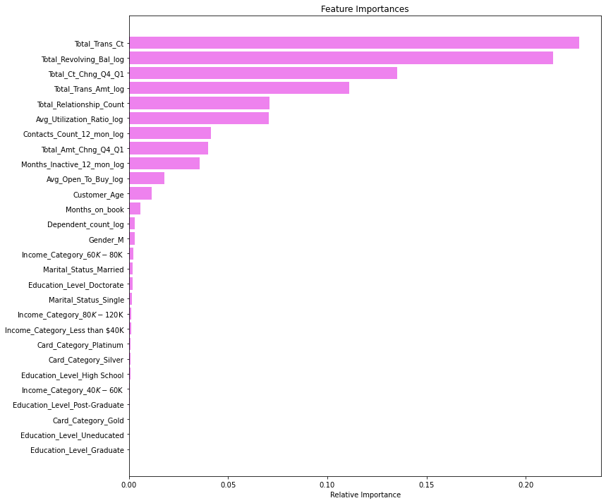

```python
importances = gbc_tuned.feature_importances_
indices = np.argsort(importances)
feature_names = list(X.columns)

plt.figure(figsize=(12,12))
plt.title('Feature Importances')
plt.barh(range(len(indices)), importances[indices], color='violet', align='center')
plt.yticks(range(len(indices)), [feature_names[i] for i in indices])
plt.xlabel('Relative Importance')
plt.show()
```

Productionize the model

- Create a final model using pipelines

```python
from sklearn.pipeline import Pipeline, make_pipeline
```

```python
from sklearn.compose import ColumnTransformer
from sklearn.preprocessing import StandardScaler, MinMaxScaler, OneHotEncoder
from sklearn.preprocessing import FunctionTransformer
log_features=['Dependent_count',
              'Months_Inactive_12_mon',
              'Contacts_Count_12_mon',
              'Avg_Open_To_Buy',
              'Avg_Utilization_Ratio',
              'Total_Revolving_Bal',
              'Total_Trans_Amt']
def log_trans(x):
    return np.log(x+1)
logtrans=FunctionTransformer(log_trans)

numerical_features = [
    "Customer_Age",
    "Dependent_count",
    "Months_on_book",
    "Total_Relationship_Count",
    "Months_Inactive_12_mon",
    "Contacts_Count_12_mon",
    "Total_Revolving_Bal",
    "Avg_Open_To_Buy",
    "Total_Trans_Amt",
    "Total_Trans_Ct",
    "Total_Ct_Chng_Q4_Q1",
    "Total_Amt_Chng_Q4_Q1",
    "Avg_Utilization_Ratio",
]


numeric_transformer = Pipeline(steps=[("imputer", SimpleImputer(strategy="median")),("zscore",StandardScaler())])


# creating a list of categorical variables
categorical_features = ["Gender",
                        "Education_Level",
                       "Marital_Status",
                       "Income_Category",
                       "Card_Category",]

# creating a transformer for categorical variables, which will first apply simple imputer and
#then do one hot encoding for categorical variables
categorical_transformer = Pipeline(
    steps=[
        ("imputer", SimpleImputer(strategy="most_frequent")),
        ("onehot", OneHotEncoder(handle_unknown="ignore")),
    ]
)
# handle_unknown = "ignore", allows model to handle any unknown category in the test data

# combining categorical transformer and numerical transformer using a column transformer

preprocessor = ColumnTransformer(
    transformers=[
        ("log",logtrans,log_features),
        ("num", numeric_transformer, numerical_features),
        ("cat", categorical_transformer, categorical_features),
    ],
    remainder="passthrough",
)
# remainder = "passthrough" has been used, it will allow variables that are present in original data
# but not in "numerical_columns" and "categorical_columns" to pass through the column transformer without any changes
```

```python
# Separating target variable and other variables
X = Bank.drop("Attrition_Flag", axis=1)
X.drop(['Credit_Limit'], axis=1, inplace=True)
X.drop(['CLIENTNUM'], axis=1, inplace=True)
Y = Bank["Attrition_Flag"]
```

```python
# Splitting the data into train and test sets
X_train, X_test, y_train, y_test = train_test_split(
    X, Y, test_size=0.30, random_state=1, stratify=Y
)
print(X_train.shape, X_test.shape)
```

```
(7088, 18) (3039, 18)
```

```python
# Creating new pipeline with best parameters
model = Pipeline(
    steps=[
        ("pre", preprocessor),
        (
            "GBC",
            GradientBoostingClassifier(
subsample=0.8, n_estimators=250, max_features=0.8
            ),
        ),
    ]
)
# Fit the model on training data
model.fit(X_train, y_train)
```

```
Pipeline(steps=[('pre',
                 ColumnTransformer(remainder='passthrough',
                                   transformers=[('log',
                                                  FunctionTransformer(func=<function log_trans at 0x00000173421910D0>),
                                                  ['Dependent_count',
                                                   'Months_Inactive_12_mon',
                                                   'Contacts_Count_12_mon',
                                                   'Avg_Open_To_Buy',
                                                   'Avg_Utilization_Ratio',
                                                   'Total_Revolving_Bal',
                                                   'Total_Trans_Amt']),
                                                 ('num',
                                                  Pipeline(steps=[('imputer',
                                                                   SimpleImpute...
                                                   'Total_Ct_Chng_Q4_Q1',
                                                   'Total_Amt_Chng_Q4_Q1',
                                                   'Avg_Utilization_Ratio']),
                                                 ('cat',
                                                  Pipeline(steps=[('imputer',
                                                                   SimpleImputer(strategy='most_frequent')),
                                                                  ('onehot',
                                                                   OneHotEncoder(handle_unknown='ignore'))]),
                                                  ['Gender', 'Education_Level',
                                                   'Marital_Status',
                                                   'Income_Category',
                                                   'Card_Category'])])),
                ('GBC',
                 GradientBoostingClassifier(max_features=0.8, n_estimators=250,
                                            subsample=0.8))])
```

Actionable Insights & Recommendations

- Business recommendations and insights

1 Total transaction count is seen to be the most important and seen to realted psotiively with existing customers, so we should look at this to see who may attrite and focus on getting thgose with low counts up, maybe with insentives 2 Total revenue balance is also important and again positvely related to exisitng customers. encoruage customers to have more money with us and to save when possible. Maybe have rewards for those with balances above an amount to encourage more money being invested and kept with us 3 Total Ct Chng Q4 Q1 is both impoortant and positively related to exisitng custiomers. Look at clients who do not uise their cards a lot during later months to see if we can encoruage them to use them more. Maybe have a holiday deal or similiar 4 Total transaction amount isboth impoortant and positively related to exisitng customers. This one is easy, simply look into ways to increase the amount our cards are used, wioth rewards or three abilitty to put off a payment maybe 5 Total relation count is onmce again is both impoortant and positively related to exisitng customers.Encoruage existing cutomers to have more products through great rates or use bank visits to talk to them about new cards or products 6 Avergae utilization ratio is, again, both impoortant and positively related to exisitng customers. Encourage customers to go up to their limit by having flexible payment plans or perhaps encouraging them to get cards with lower limits, assuming this wouldn't impact total transaction amount